# Dataset

My Dataset was taken from Kaggle (https://www.kaggle.com/datasets/rashikrahmanpritom/disney-movies-19372016-total-gross)

**Walt Disney Studios Movie Information:** Gross is a significant indicator of movie performance. This data frame consists of 579 Disney movies and their corresponding details from 1937 through 2016. Analyzing the Disney Movies' Total Gross dataset over time will yield insight into the results and visualizations for the following questions:

1. *Top 10 highest grossing Disney movies adjusted for inflation*
2. *Top 10 lowest grossing Disney movies adjusted for inflation*
3. *Top 10 highest grossing Disney movies in the 21st Century adjusted for inflation*
4. *Top 10 highest grossing Disney musicals adjusted for inflation*
5. *In which decade did Walt Disney Studios films have the highest average gross adjusted for inflation*
6. *Which genre of film has the highest average gross adjusted for inflation*
7. *Which MPAA rating type has the highest average gross adjusted for inflation*
8. *Is there a correlation between length of movie title and gross adjusted for inflation*
9. *How many movies has Disney produced under each genre category*

# Imports

```python
import pandas as pd
import numpy as np
import matplotlib.pyplot as plt
data = pd.read_csv("data/disney_movies_total_gross.csv")
```

# Exploring the Data

### Row Count

Identify the number of lines in the dataset

```python
!wc -l "data/disney_movies_total_gross.csv"
```

```
580 data/disney_movies_total_gross.csv
```

### Shape

Display the shape of the DataFrame, which has the format: (# rows, # columns)

```python
data.shape
```

```
(579, 6)
```

### Display the Columns

```python
data.columns
```

```
Index(['movie_title', 'release_date', 'genre', 'mpaa_rating', 'total_gross',
       'inflation_adjusted_gross'],
      dtype='object')
```

#### Column Datatypes

Further understand the data by displaying the data type for each column in the DataFrame.

```python
data.dtypes
```

```
movie_title                 object
release_date                object
genre                       object
mpaa_rating                 object
total_gross                  int64
inflation_adjusted_gross     int64
dtype: object
```

### Display the Rows

The row count indicates the file is large in size. Instead of displaying the entire dataset, revealing only the head and tail of the dataset should provide ample information to understand the nature of the data.

#### View the Top 5 Entries

```python
data.head()
```

|  | movie_title | release_date | genre | mpaa_rating | total_gross | inflation_adjusted_gross |
| --- | --- | --- | --- | --- | --- | --- |
| 0 | Snow White and the Seven Dwarfs | 1937-12-21 | Musical | G | 184925485 | 5228953251 |
| 1 | Pinocchio | 1940-02-09 | Adventure | G | 84300000 | 2188229052 |
| 2 | Fantasia | 1940-11-13 | Musical | G | 83320000 | 2187090808 |
| 3 | Song of the South | 1946-11-12 | Adventure | G | 65000000 | 1078510579 |
| 4 | Cinderella | 1950-02-15 | Drama | G | 85000000 | 920608730 |

#### View the Last 5 Entries

```python
data.tail()
```

|  | movie_title | release_date | genre | mpaa_rating | total_gross | inflation_adjusted_gross |
| --- | --- | --- | --- | --- | --- | --- |
| 574 | The Light Between Oceans | 2016-09-02 | Drama | PG-13 | 12545979 | 12545979 |
| 575 | Queen of Katwe | 2016-09-23 | Drama | PG | 8874389 | 8874389 |
| 576 | Doctor Strange | 2016-11-04 | Adventure | PG-13 | 232532923 | 232532923 |
| 577 | Moana | 2016-11-23 | Adventure | PG | 246082029 | 246082029 |
| 578 | Rogue One: A Star Wars Story | 2016-12-16 | Adventure | PG-13 | 529483936 | 529483936 |

### Data Analysis

**The exploratory process yields several conclusions about the data:**

- The rows are arranged by release date in ascending order (from earliest release to most recent)
- There are 580 total lines in the data frame; however, the initial isn't an entry as it contains the column headers
- There are 579 rows -- a claim supported by the shape of the data
- There are 6 columns

# Cleaning the Data

### Check for Null Values

```python
data.isnull().sum()
```

```
movie_title                  0
release_date                 0
genre                       17
mpaa_rating                 56
total_gross                  0
inflation_adjusted_gross     0
dtype: int64
```

The tabular results convey that two columns contain null values. Nevertheless, I will refrain from dropping the rows with nulls because omitted column information does not undermine the derived insight of rows. Nulls exist within the genre and mpaa_rating columns -- columns nonintegral to several calculations seeking to analyze the data. The dataset examines the total gross of Disney films, where gross constitutes the requisite data for analysis. I decided to refrain from dropping any rows based on the presence of nulls since no null values are present in either of the gross columns.

### Check for Applicable Data

```python
(data[["total_gross","inflation_adjusted_gross"]] == 0).sum()
```

```
total_gross                 4
inflation_adjusted_gross    4
dtype: int64
```

The Dataset includes non-theatrical Disney movie releases. These films were never publically shown on a silver screen and consequently do not have a recorded box office gross. As detailed above, the gross columns do not contain null values because non-theatrical films have their gross stored as zero rather than no gross (null).

It does not make sense to include movies with 0 gross due to a technicality in the considerations for analysis. For instance, their values are outliers that would likely skew the average gross to the left. Dropping these instances is imperative to ensure logical data analysis of Disney movie performance based on gross.

#### Dropping Rows with Zero Gross

```python
indexZeroGross = data[ (data["total_gross"] == 0) | (data["inflation_adjusted_gross"] == 0) ].index
data.drop(indexZeroGross, inplace = True)
(data[["total_gross","inflation_adjusted_gross"]] == 0).sum()
```

```
total_gross                 0
inflation_adjusted_gross    0
dtype: int64
```

Verifies that there are no remaining zero gross values after dropping rows from DataFrame.

### Check for Duplicate Data

```python
data.duplicated().sum()
```

```
0
```

There are 0 occurrences of duplicate rows in the Dataset.

# Preparing the Data

### Setting Index

```python
data.set_index("movie_title",inplace=True)
data
```

| movie_title | release_date | genre | mpaa_rating | total_gross | inflation_adjusted_gross |
| --- | --- | --- | --- | --- | --- |
| Snow White and the Seven Dwarfs | 1937-12-21 | Musical | G | 184925485 | 5228953251 |
| Pinocchio | 1940-02-09 | Adventure | G | 84300000 | 2188229052 |
| Fantasia | 1940-11-13 | Musical | G | 83320000 | 2187090808 |
| Song of the South | 1946-11-12 | Adventure | G | 65000000 | 1078510579 |
| Cinderella | 1950-02-15 | Drama | G | 85000000 | 920608730 |
| ... | ... | ... | ... | ... | ... |
| The Light Between Oceans | 2016-09-02 | Drama | PG-13 | 12545979 | 12545979 |
| Queen of Katwe | 2016-09-23 | Drama | PG | 8874389 | 8874389 |
| Doctor Strange | 2016-11-04 | Adventure | PG-13 | 232532923 | 232532923 |
| Moana | 2016-11-23 | Adventure | PG | 246082029 | 246082029 |
| Rogue One: A Star Wars Story | 2016-12-16 | Adventure | PG-13 | 529483936 | 529483936 |

575 rows × 5 columns

Sets the movie_title column as an index. An index serves as a label identifier for each row.

### Change Column Type

The data exploration process found that the release_date column has type Object. To more suitably manipulate the data more, we convert this column to the DateTime type.

```python
data["release_date"] = pd.to_datetime(data["release_date"])
data.dtypes
```

```
release_date                datetime64[ns]
genre                               object
mpaa_rating                         object
total_gross                          int64
inflation_adjusted_gross             int64
dtype: object
```

### Create Column

Create a new column called release_year to store the release year of each Disney movie. The DateTime command dt.year gets the year data from the entire date.

```python
data["release_year"] = data["release_date"].dt.year
data.head()
```

| movie_title | release_date | genre | mpaa_rating | total_gross | inflation_adjusted_gross | release_year |
| --- | --- | --- | --- | --- | --- | --- |
| Snow White and the Seven Dwarfs | 1937-12-21 | Musical | G | 184925485 | 5228953251 | 1937 |
| Pinocchio | 1940-02-09 | Adventure | G | 84300000 | 2188229052 | 1940 |
| Fantasia | 1940-11-13 | Musical | G | 83320000 | 2187090808 | 1940 |
| Song of the South | 1946-11-12 | Adventure | G | 65000000 | 1078510579 | 1946 |
| Cinderella | 1950-02-15 | Drama | G | 85000000 | 920608730 | 1950 |

# Analytics

### 1. *Highest Grossing Walt Disney Studios Films (Adjusted for Inflation)*

The following code sorts the Dataset by the inflation-adjusted gross column in descending order and slices the results to retrieve the initial ten entries. Instead of reordering the data frame by the inflation_adjusted_gross column contents, this code snippet sorts the data and copies the top ten inflation-adjusted movies to another variable without changing the contents.

```python
top_gross_adj = data.sort_values("inflation_adjusted_gross", ascending = False)[0:10].copy()
top_gross_adj
```

| movie_title | release_date | genre | mpaa_rating | total_gross | inflation_adjusted_gross | release_year |
| --- | --- | --- | --- | --- | --- | --- |
| Snow White and the Seven Dwarfs | 1937-12-21 | Musical | G | 184925485 | 5228953251 | 1937 |
| Pinocchio | 1940-02-09 | Adventure | G | 84300000 | 2188229052 | 1940 |
| Fantasia | 1940-11-13 | Musical | G | 83320000 | 2187090808 | 1940 |
| 101 Dalmatians | 1961-01-25 | Comedy | G | 153000000 | 1362870985 | 1961 |
| Lady and the Tramp | 1955-06-22 | Drama | G | 93600000 | 1236035515 | 1955 |
| Song of the South | 1946-11-12 | Adventure | G | 65000000 | 1078510579 | 1946 |
| Star Wars Ep. VII: The Force Awakens | 2015-12-18 | Adventure | PG-13 | 936662225 | 936662225 | 2015 |
| Cinderella | 1950-02-15 | Drama | G | 85000000 | 920608730 | 1950 |
| The Jungle Book | 1967-10-18 | Musical | Not Rated | 141843000 | 789612346 | 1967 |
| The Lion King | 1994-06-15 | Adventure | G | 422780140 | 761640898 | 1994 |

#### 1. *Insight*

Disney's three earliest films prove to be their three highest-grossing films, with the eldest at the top of the chart. Walt Disney Studios has not rediscovered the magic brought to fruition in their beginning years. None of Disney's hundreds of productions have surpassed their debut movie. Moreover, it is clear that the ceiling for the general audience 'G' rating is higher than all other ratings -- eight out of the top ten movies on this list are rated 'G.' Star Wars Ep. VII: The Force Awakens is a surprise feature on this list as it is the only film from the 21st Century to make it. In addition, this data was recorded up until late 2016, so the film amassed enough gross within the span of a year than most Disney films did in their lifetime. This is likely due to a large gap between the last installment of the Star Wars franchise and the first under Disney's ownership of Lucasfilm.

### 2. *Lowest Grossing Walt Disney Studios Films (Adjusted for Inflation)*

The subsequent code sorts the data in the inflation_adjusted_gross column in ascending order, which is the opposite of the previous implementation. As a result, the lowest ten inflation-adjusted grossing Disney films are displayed.

```python
bot_gross_adj = data.sort_values("inflation_adjusted_gross", ascending = True)[0:10].copy()
bot_gross_adj
```

| movie_title | release_date | genre | mpaa_rating | total_gross | inflation_adjusted_gross | release_year |
| --- | --- | --- | --- | --- | --- | --- |
| Zokkomon | 2011-04-22 | Adventure | PG | 2815 | 2984 | 2011 |
| Walt and El Grupo | 2009-09-10 | Documentary | PG | 20521 | 23064 | 2009 |
| Gedo Senki (Tales from Earthsea) | 2010-08-13 | Adventure | PG-13 | 48658 | 51988 | 2010 |
| The War at Home | 1996-11-20 | NaN | R | 34368 | 65543 | 1996 |
| An Alan Smithee Film: Burn Hollywood … | 1998-02-27 | Comedy | R | 45779 | 82277 | 1998 |
| Waking Sleeping Beauty | 2010-03-26 | Documentary | PG | 80741 | 86264 | 2010 |
| It's Pat | 1994-08-26 | Comedy | NaN | 60822 | 125666 | 1994 |
| Goal! 2: Living the Dream... | 2008-08-29 | Drama | PG-13 | 225067 | 264247 | 2008 |
| Breakfast of Champions | 1999-09-17 | Comedy | R | 178287 | 295851 | 1999 |
| Morning Light | 2008-10-17 | Documentary | PG | 275093 | 322979 | 2008 |

#### 2. *Insight*

Unlike Disney's top-grossing films, this table depicting the worst-performing Walt Disney Studios productions contains multiple R MPAA ratings. The public regards Disney as a family-oriented company, so moviegoers will likely not seek out R-rated Disney movies because the brand is not known for them. The late 2000s and early 2010s appear to have had several low-grossing movies. Zokkoman grossed a measly two-thousand and eight hundred dollars despite being an adventure movie -- a genre that normally performs exceptionally well for Disney. Noticeably, there are no G-rated movies on this list, which further compounds the idea that Disney is known for its family productions. On the other hand, multiple documentaries find themselves in the bottom ten-grossing Disney films. These results can be explained by children's disinterest in non-fiction-based recountings.

### 3. *Highest Grossing Inflation-Adjusted Walt Disney Studio Films in the 21st Century*

Line one in the following code block locates the entries with release dates occuring after the turn of the century. The next step sorts the remaining rows based on the data for inflation_adjusted_gross in descending order. The outputted table takes inflation into account and displays the ten highest grossing Disney movies from 2000 through 2016.

```python
this_century = data.loc[data["release_date"] >= "2000-01-01"]
top_gross_21st = this_century.sort_values("inflation_adjusted_gross", ascending = False)[0:10].copy()
top_gross_21st
```

| movie_title | release_date | genre | mpaa_rating | total_gross | inflation_adjusted_gross | release_year |
| --- | --- | --- | --- | --- | --- | --- |
| Star Wars Ep. VII: The Force Awakens | 2015-12-18 | Adventure | PG-13 | 936662225 | 936662225 | 2015 |
| The Avengers | 2012-05-04 | Action | PG-13 | 623279547 | 660081224 | 2012 |
| Pirates of the Caribbean: Dead Man’… | 2006-07-07 | Adventure | PG-13 | 423315812 | 544817142 | 2006 |
| Rogue One: A Star Wars Story | 2016-12-16 | Adventure | PG-13 | 529483936 | 529483936 | 2016 |
| Finding Nemo | 2003-05-30 | Adventure | G | 380529370 | 518148559 | 2003 |
| Finding Dory | 2016-06-17 | Adventure | PG | 486295561 | 486295561 | 2016 |
| Avengers: Age of Ultron | 2015-05-01 | Action | PG-13 | 459005868 | 459005868 | 2015 |
| Toy Story 3 | 2010-06-18 | Adventure | G | 415004880 | 443408255 | 2010 |
| Pirates of the Caribbean: The Curse o… | 2003-07-09 | Adventure | PG-13 | 305411224 | 426967926 | 2003 |
| Iron Man 3 | 2013-05-03 | Action | PG-13 | 408992272 | 424084233 | 2013 |

#### 3. *Insight*

In all of Disney's 21st-century movies, adventure performed the best -- constituting seven out of the top ten slots. The three films to steal placements from the adventure genre were all Marvel superhero movies of the action genre. This list also details a shift to the prominence of franchises or films in a series. Every movie in this top ten-grossing list of the 21st century has spinoffs or is part of a film series. It appears that certain things work at the box office, and Disney is taking advantage of that. Once known for their princess movies, Disney is now much more in this day and age as shown by the lack of Tangled and Frozen in this table.

### 4. *Highest Grossing Walt Disney Studios Musicals (Adjusted for Inflation)*

The code below locates every instance in the dataset with musical as the genre. It proceeds to sort the selection of musicals by inflation-adjusted gross in descending order. Slicing the top ten rows yields information about the ten highest-grossing Disney musicals with inflation accounted for.

```python
musicals = data.loc[data["genre"] == "Musical"]
top_gross_musical = musicals.sort_values("inflation_adjusted_gross", ascending = False)[0:10].copy()
top_gross_musical
```

| movie_title | release_date | genre | mpaa_rating | total_gross | inflation_adjusted_gross | release_year |
| --- | --- | --- | --- | --- | --- | --- |
| Snow White and the Seven Dwarfs | 1937-12-21 | Musical | G | 184925485 | 5228953251 | 1937 |
| Fantasia | 1940-11-13 | Musical | G | 83320000 | 2187090808 | 1940 |
| The Jungle Book | 1967-10-18 | Musical | Not Rated | 141843000 | 789612346 | 1967 |
| Beauty and the Beast | 1991-11-13 | Musical | G | 218951625 | 363017667 | 1991 |
| The Aristocats | 1970-04-24 | Musical | G | 55675257 | 255161499 | 1970 |
| Into the Woods | 2014-12-25 | Musical | PG | 128002372 | 130894237 | 2014 |
| Babes in Toyland | 1961-12-14 | Musical | G | 10218316 | 124841160 | 1961 |
| High School Musical 3: Senior Year | 2008-10-24 | Musical | G | 90559416 | 106308538 | 2008 |
| The Nightmare Before Christmas | 1993-10-13 | Musical | PG | 50408318 | 100026637 | 1993 |
| Fantasia 2000 (IMAX) | 2000-01-01 | Musical | G | 60507228 | 94852354 | 2000 |

#### 4. *Insight*

Musicals are a huge category for Walt Disney Studios. However, there is a huge disparity between the number one and the number 10 highest grossing Disney musicals -- a 5.1 billion difference. Disney musicals are likely rated for general audiences (G), but Into the Woods proves that PG musicals can gross incredibly well. Musicals from all ages have found a spot in the top 10. This shows that musicals can be successful no matter what era they are in.

### 5. *Which Decade did Disney Movies Gross the Highest on Average (Inflation Adjusted)*

To organize the data into decades, we establish the bounds to determine the number of decades we will look at. Using the Arange method, we generate an array containing the starting year of each decade. This method takes a start index, an end index, and a step value to return an array containing the year at the beginning of each decade.

We use this array to create a tuple where the zero position contains the array's decade start value, and the one position in the tuple gets the end bound for the decade by adding ten to the start.

This tuple allows us to generate a bin with specific ranges of index values using the IntervalIndex method.

We then plug the release_year column values into the pandas cut method to compare to the bin value, and if the value is within a decade's range, the entry gets that particular decade. As a result, we can add a new decade column storing the corresponding decade for each entry.

The bin labels in the form [start, end) constitute the decade column values following this code snippet. However, we replace these values with cleaner labels using a dictionary replace, which checks if DataFrame values match any of its keys and replace them with their respective values if found.

```python
start_year = 1930
end_year = 2017
decades = np.arange(start_year, end_year, 10).tolist()

tuples = [(start, start + 10) for start in decades]
bins = pd.IntervalIndex.from_tuples(tuples, closed = "left")

data["decade"] = pd.cut(data["release_year"],
                        bins = bins,
                        include_lowest = True)

bin_labels = list(bins.astype(str))
decade_labels = ['{}s'.format(str(d)) for d in decades]
dictionary = dict(zip(bin_labels, decade_labels))

data["decade"] = data["decade"].astype(str)
data = data.replace(dictionary)

decade_data = data.reset_index().filter(["inflation_adjusted_gross", "decade"], axis = 1).groupby("decade").mean()
decade_data
```

| decade | inflation_adjusted_gross |
| --- | --- |
| 1930s | 5.228953e+09 |
| 1940s | 1.817943e+09 |
| 1950s | 6.766075e+08 |
| 1960s | 4.270692e+08 |
| 1970s | 1.328689e+08 |
| 1980s | 7.858560e+07 |
| 1990s | 7.518349e+07 |
| 2000s | 9.234797e+07 |
| 2010s | 1.529127e+08 |

Manipulating this Decades DataFrame allows us to determine which decade in Walt Disney Studios history had the highest average inflation-adjusted gross. There is no need for slicing in this sort function because grouping by decades reduces the DataFrame rows count to a manageable amount.

```python
top_decade = decade_data.sort_values("inflation_adjusted_gross", ascending = False).copy()
top_decade.rename(columns = {"inflation_adjusted_gross":"avgerage gross"}, inplace = True)
top_decade
```

| decade | avgerage gross |
| --- | --- |
| 1930s | 5.228953e+09 |
| 1940s | 1.817943e+09 |
| 1950s | 6.766075e+08 |
| 1960s | 4.270692e+08 |
| 2010s | 1.529127e+08 |
| 1970s | 1.328689e+08 |
| 2000s | 9.234797e+07 |
| 1980s | 7.858560e+07 |
| 1990s | 7.518349e+07 |

There exists a single entry in the 1930s decade, meaning the average gross for the entire decade is the value of the only movie published during it.

#### *Average Inflation-Adjusted Gross Per Decade Visualization*

```
<function matplotlib.pyplot.show(close=None, block=None)>
```

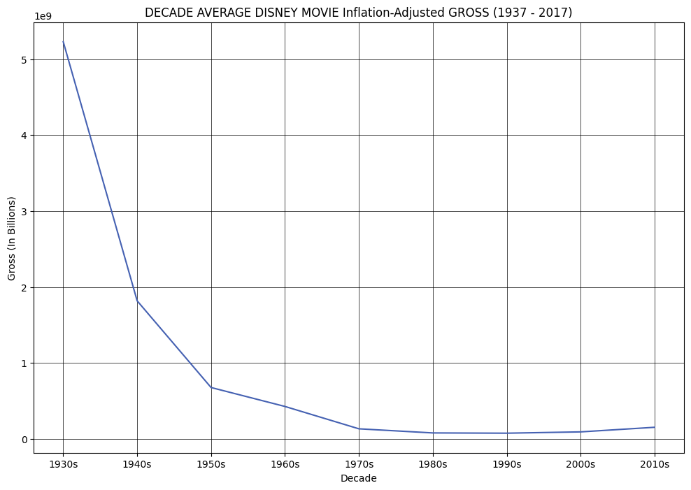

```python
fig = plt.figure()
fig.set_figwidth(12)
fig.set_figheight(8)

decade_data.reset_index(inplace = True)
plt.plot(decade_data["decade"],
        decade_data["inflation_adjusted_gross"],
        color = "#4561b2")

plt.title("DECADE AVERAGE DISNEY MOVIE Inflation-Adjusted GROSS (1937 - 2017)")
plt.xlabel("Decade")
plt.ylabel("Gross (In Billions)")

plt.grid(color = "#000000", linewidth = 0.5)

plt.show
```

### 6. *In Which Genre of Film does Disney Gross Highest on Average (Inflation Adjusted)*

The following code copies the genre and inflation gross columns from the original data set and adds them to another. This new data frame groups the entries into their respective genres and calculates the mean gross of each genre. The average gross of a genre can be calculated by summing the inflation-adjusted gross of every movie in that genre and dividing it by the number of addends. The mean() method simplifies this process. The outputted gross is written in scientific notation.

```python
top_gross_genre = data.dropna(
        how = "all", subset = ["genre"]).reset_index().filter(
        ["genre", "inflation_adjusted_gross"], axis = 1).groupby("genre").mean()
top_gross_genre.sort_values("inflation_adjusted_gross", ascending = False)
```

| genre | inflation_adjusted_gross |
| --- | --- |
| Musical | 6.035979e+08 |
| Adventure | 1.903974e+08 |
| Action | 1.409984e+08 |
| Thriller/Suspense | 8.965379e+07 |
| Comedy | 8.466773e+07 |
| Romantic Comedy | 7.777708e+07 |
| Western | 7.381571e+07 |
| Drama | 7.252924e+07 |
| Concert/Performance | 5.741084e+07 |
| Black Comedy | 5.224349e+07 |
| Horror | 2.341385e+07 |
| Documentary | 1.271803e+07 |

#### *Average Genre Gross Visualization*

```
<function matplotlib.pyplot.show(close=None, block=None)>
```

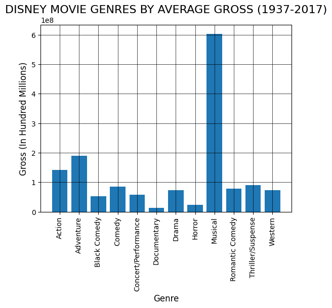

```python
fig = plt.figure()
fig.set_figwidth(12)
fig.set_figheight(8)

top_gross_genre.reset_index(inplace = True)
top_gross_genre.sort_values("genre", ascending = True)
genres = top_gross_genre["genre"]
gross = top_gross_genre["inflation_adjusted_gross"]

fig,ax = plt.subplots(nrows = 1, ncols = 1)
ax.bar(genres,
       gross,
       align = "center")

plt.title("DISNEY MOVIE GENRES BY AVERAGE GROSS (1937-2017)",
         fontsize = 16)
plt.xlabel("Genre",
          fontsize = 12)
plt.ylabel("Gross (In Hundred Millions)",
          fontsize = 12)
plt.xticks(rotation = "vertical")

plt.grid(color = "#000000", linewidth = 0.5)

plt.show
```

#### 6. *Insight*

Musicals are by far the highest grossing genre in Disney's history. Only three genres gross higher than one hundred million on average, musicals being the greatest of the three. Grossing more than three times the second on the list, musicals perform the best for Disney. With these results, Disney should continue to craft musicals to improve their earnings. On the other hand, documentaries perform lowest out of all genres, which is likely due to the lack of imagination and wonder that Disney is known for in these productions.

### 7. *Under Which MPAA Rating Do Disney Movies have the Highest Average Gross*

Previously, we refrained from dropping entries with null values in the MPAA rating columns. The following code assigns a copy of the original data with all nulls removed to the drop_null_data data frame. We then filter the data frame to only contain the MPAA category column and the inflation-adjusted gross column. Grouping the hundreds of contents into their respective MPAA ratings and calculating each category's mean produces tabular data. The final step is sorting the data by gross in descending order to get the highest rating in terms of gross first.

```python
drop_null_data = data.dropna(how = "all", subset = ["mpaa_rating"])
top_gross_mpaa = drop_null_data.reset_index().filter(
    ["mpaa_rating", "inflation_adjusted_gross"], axis = 1).groupby("mpaa_rating").mean()
top_gross_mpaa.sort_values("inflation_adjusted_gross", ascending = False)
```

| mpaa_rating | inflation_adjusted_gross |
| --- | --- |
| Not Rated | 2.998734e+08 |
| G | 2.912610e+08 |
| PG-13 | 1.029486e+08 |
| PG | 1.015414e+08 |
| R | 5.530581e+07 |

#### *MPAA Rating Average Gross For Disney Movies Visualization*

```
<function matplotlib.pyplot.show(close=None, block=None)>
```

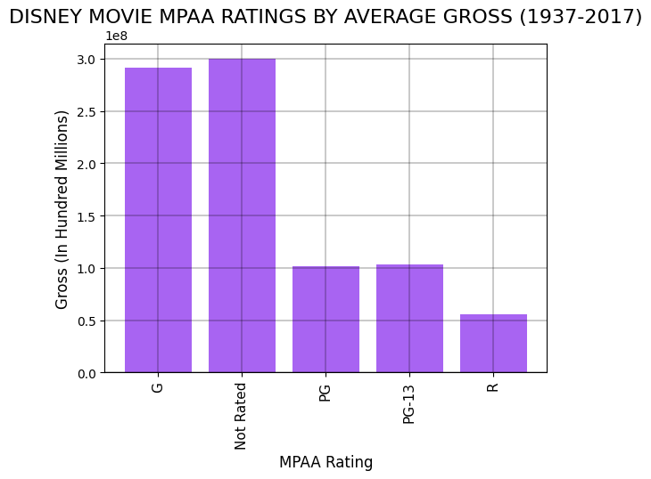

```python
fig = plt.figure()
fig.set_figwidth(10)
fig.set_figheight(6)

top_gross_mpaa.reset_index(inplace = True)
top_gross_mpaa.sort_values("mpaa_rating", ascending = True)
ratings = top_gross_mpaa["mpaa_rating"]
gross = top_gross_mpaa["inflation_adjusted_gross"]

fig,ax = plt.subplots(nrows = 1, ncols = 1)
ax.bar(ratings,
       gross,
       align = "center",
       color = "#a864f2")

plt.title("DISNEY MOVIE MPAA RATINGS BY AVERAGE GROSS (1937-2017)",
         fontsize = 16)
plt.xlabel("MPAA Rating",
          fontsize = 12)
plt.ylabel("Gross (In Hundred Millions)",
          fontsize = 12)
plt.xticks(rotation = "vertical",
          fontsize = 11)

plt.grid(color = "#000000", linewidth = 0.3)

plt.show
```

#### 7 *Insights*

Despite constituting most of the top 10 highest grossing Disney movies of all time, G-rated movies perform slightly worse than Not rated movies on average. The smaller size pool of Not Rated movies allows its mean to outperform Disney's illustrious G movie category. Furthermore, it is no surprise that R-rated Disney movies have the lowest average gross out of all of the ratings. R-rated Disney movies are few and far between, and they are not what the usual Disney audience is looking to see.